# Titanic

# 1 Introduction

This dataset is from Kaggle’s machine learning project based where participants are to predict if passengers survived or not. It requires feature engineering, missing value correction, outlier correction, and random forests to come up with a model.

### 1.1 Loading libraries

```r
library(data.table)
library(dplyr)
library(ggplot2)
library(ggthemes)
library(randomForest)
library(tidyr)
library(caret)
```

We will be using data.table for this project

```r
#Convert to data table
titanic <- as.data.table(titanic)
```

### 1.2 Initial glance at the data

```r
#Data exploration
head(titanic)
```

```
##    PassengerId Survived Pclass
## 1:           1        0      3
## 2:           2        1      1
## 3:           3        1      3
## 4:           4        1      1
## 5:           5        0      3
## 6:           6        0      3
##                                                   Name    Sex Age SibSp
## 1:                             Braund, Mr. Owen Harris   male  22     1
## 2: Cumings, Mrs. John Bradley (Florence Briggs Thayer) female  38     1
## 3:                              Heikkinen, Miss. Laina female  26     0
## 4:        Futrelle, Mrs. Jacques Heath (Lily May Peel) female  35     1
## 5:                            Allen, Mr. William Henry   male  35     0
## 6:                                    Moran, Mr. James   male  NA     0
##    Parch           Ticket    Fare Cabin Embarked
## 1:     0        A/5 21171  7.2500              S
## 2:     0         PC 17599 71.2833   C85        C
## 3:     0 STON/O2. 3101282  7.9250              S
## 4:     0           113803 53.1000  C123        S
## 5:     0           373450  8.0500              S
## 6:     0           330877  8.4583              Q
```

```r
str(titanic)
```

```
## Classes 'data.table' and 'data.frame':   891 obs. of  12 variables:
##  $ PassengerId: int  1 2 3 4 5 6 7 8 9 10 ...
##  $ Survived   : int  0 1 1 1 0 0 0 0 1 1 ...
##  $ Pclass     : int  3 1 3 1 3 3 1 3 3 2 ...
##  $ Name       : chr  "Braund, Mr. Owen Harris" "Cumings, Mrs. John Bradley (Florence Briggs Thayer)" "Heikkinen, Miss. Laina" "Futrelle, Mrs. Jacques Heath (Lily May Peel)" ...
##  $ Sex        : chr  "male" "female" "female" "female" ...
##  $ Age        : num  22 38 26 35 35 NA 54 2 27 14 ...
##  $ SibSp      : int  1 1 0 1 0 0 0 3 0 1 ...
##  $ Parch      : int  0 0 0 0 0 0 0 1 2 0 ...
##  $ Ticket     : chr  "A/5 21171" "PC 17599" "STON/O2. 3101282" "113803" ...
##  $ Fare       : num  7.25 71.28 7.92 53.1 8.05 ...
##  $ Cabin      : chr  "" "C85" "" "C123" ...
##  $ Embarked   : chr  "S" "C" "S" "S" ...
##  - attr(*, ".internal.selfref")=<externalptr>
```

```r
#Let's do a quick convert to factors for a few of our features
titanic$Survived <- as.factor(titanic$Survived)
titanic$Pclass <- as.factor(titanic$Pclass)
titanic$Sex <- as.factor(titanic$Sex)
titanic$Embarked <- as.factor(titanic$Embarked)
```

# 2 Exploration

### 2.1 Visual exploration

Sometimes looking at numbers doesn’t tell the whole story. Let’s start with some visuals.

```r
#Create a function to be able to visualize tables and bar charts
vis1 <- function(feat){
  temp.table <- table(titanic[[feat]], titanic$Survived)
  print(temp.table)

  ggplot(titanic, aes_string(x = feat)) +
    geom_bar(aes(fill = Survived)) +
    theme_few() +
    guides(fill = guide_legend(reverse=TRUE)) +
    ylab("") +
    xlab("") +
    ggtitle(paste(feat))
}

#Create a function to be able to visualize proportions and stacked bar charts
vis2 <- function(feat){
  prop.temp  <- as.data.frame(prop.table(table(titanic[[feat]], titanic$Survived),1))
  print(prop.temp)

  ggplot(prop.temp, aes(x = Var1, y = Freq, fill = Var2)) +
    geom_bar(stat = "identity") +
    theme_few() +
    guides(fill = guide_legend(reverse=TRUE)) +
    ylab("") +
    xlab("") +
    ggtitle(paste(feat)) +
    scale_fill_discrete(name="Survived")
}
```

### 2.2 The plots

Let’s do a quick read on Survival based on Sex, Pclass, and where the passenger embarked from

### 2.3 Sex and survival

```r
#Sex and survival
vis1("Sex")
```

```
##
##            0   1
##   female  81 233
##   male   468 109
```

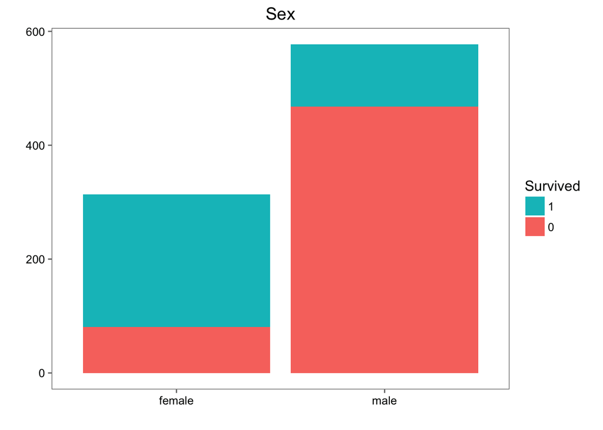

```r
vis2("Sex")
```

```
##     Var1 Var2      Freq
## 1 female    0 0.2579618
## 2   male    0 0.8110919
## 3 female    1 0.7420382
## 4   male    1 0.1889081
```

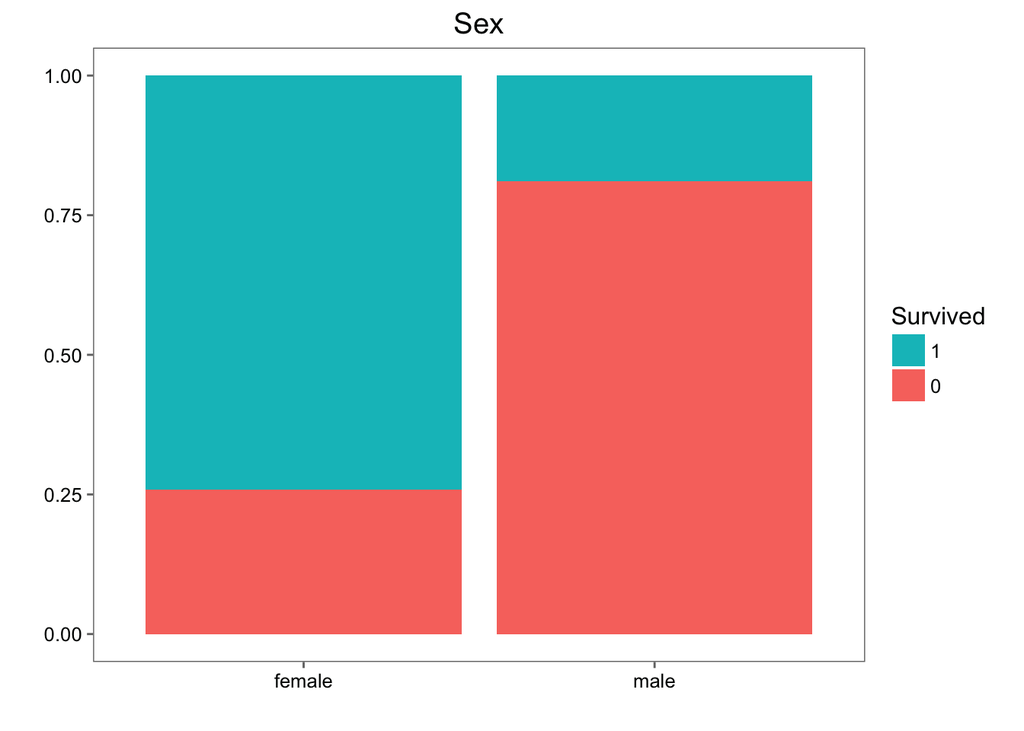

### 2.4 Pclass and survival

```r
#Pclass and survival
vis1("Pclass")
```

```
##
##       0   1
##   1  80 136
##   2  97  87
##   3 372 119
```

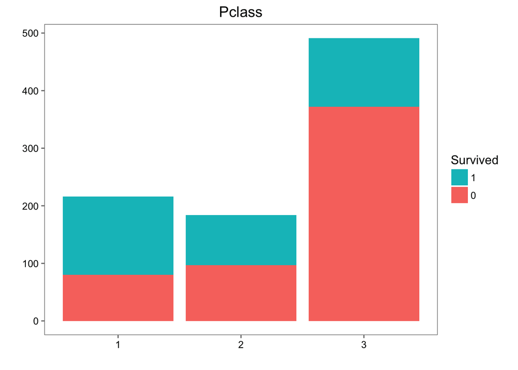

```r
vis2("Pclass")
```

```
##   Var1 Var2      Freq
## 1    1    0 0.3703704
## 2    2    0 0.5271739
## 3    3    0 0.7576375
## 4    1    1 0.6296296
## 5    2    1 0.4728261
## 6    3    1 0.2423625
```

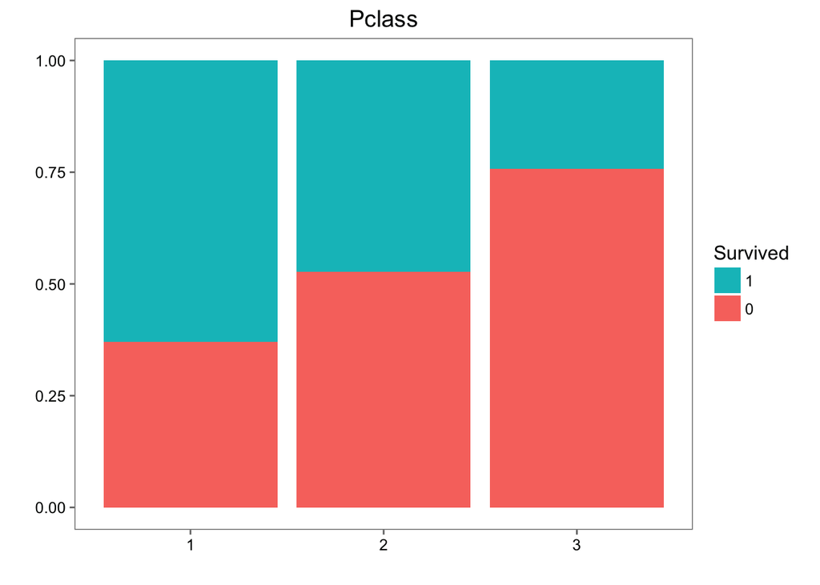

### 2.5 Embarked and survival

```r
#Embarked and survival
vis1("Embarked")
```

```
##
##       0   1
##       0   2
##   C  75  93
##   Q  47  30
##   S 427 217
```

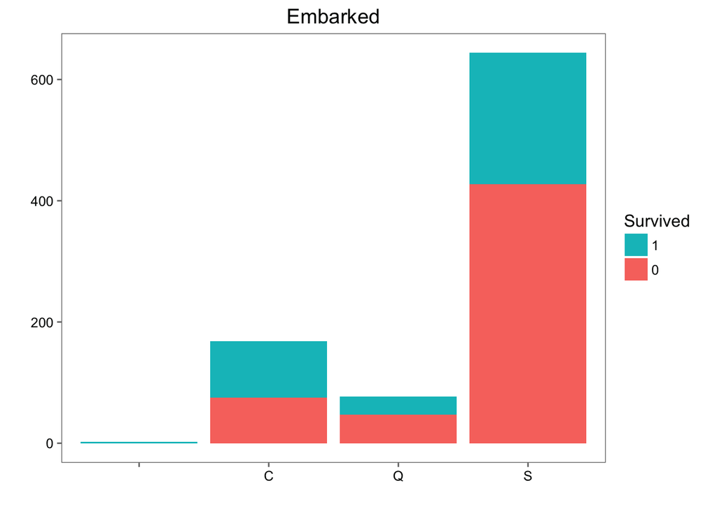

```r
vis2("Embarked")
```

```
##   Var1 Var2      Freq
## 1         0 0.0000000
## 2    C    0 0.4464286
## 3    Q    0 0.6103896
## 4    S    0 0.6630435
## 5         1 1.0000000
## 6    C    1 0.5535714
## 7    Q    1 0.3896104
## 8    S    1 0.3369565
```

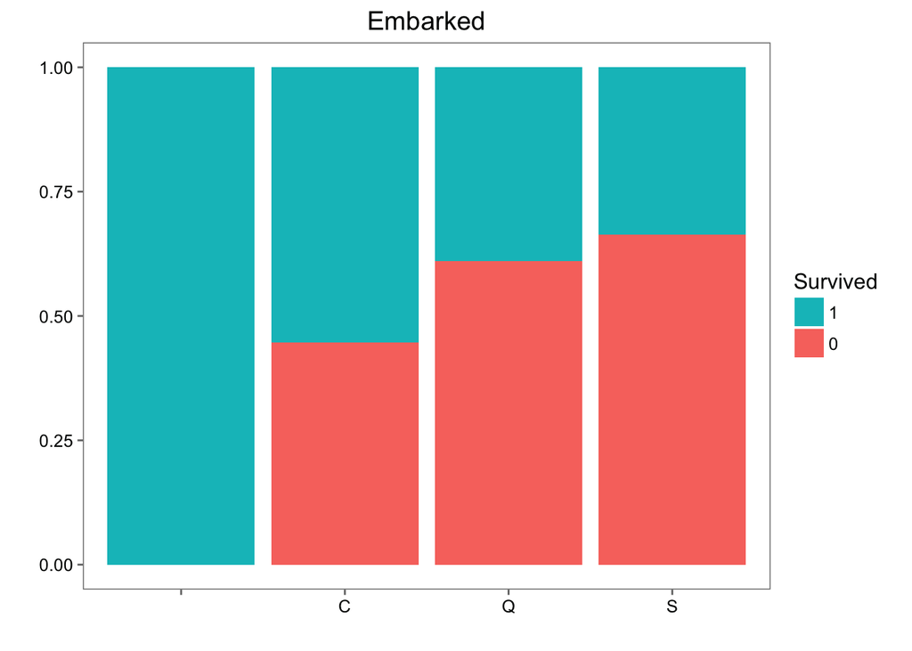

### 2.6 One step further

We can even go deeper and visualize the interaction between Pclass, Sex, and survival

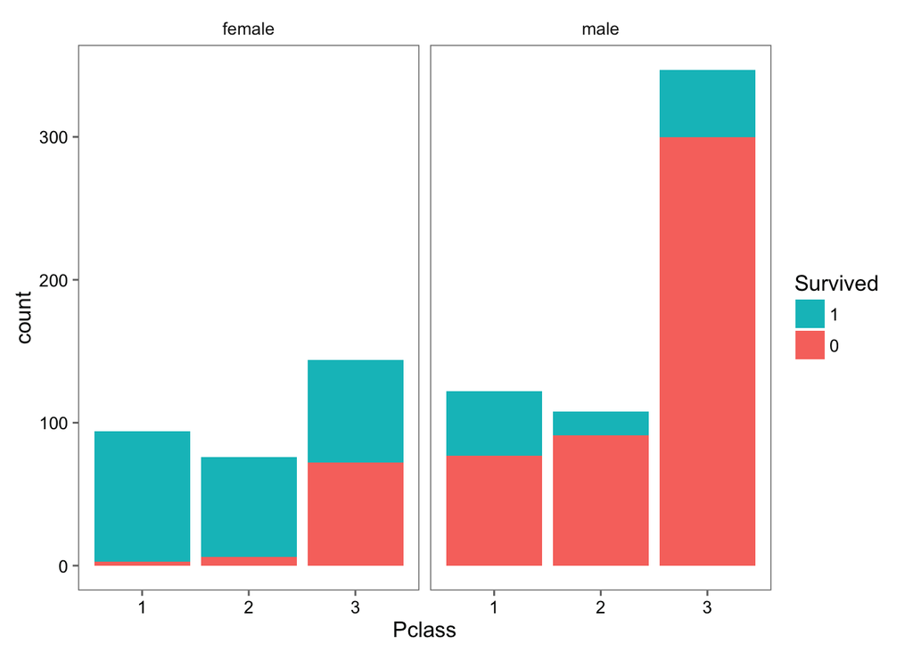

```r
#Go deeper
ggplot(titanic, aes(x = Pclass)) +
  geom_bar(aes(fill = Survived)) +
  facet_grid(~Sex) +
  theme_few() +
  guides(fill = guide_legend(reverse=TRUE))
```

We can conclude that there are some interesting relationships between sex, pclass and, survival.

# 3 Missing values

Before we go on, there are some missing data in the Embarked and Age column. We will look at Embarked first.

### 3.1 Missing embarked data

```r
#missing embarked data
table(titanic$Embarked)
```

```
##
##       C   Q   S
##   2 168  77 644
```

```r
titanic[Embarked == ""]
```

```
##    PassengerId Survived Pclass                                      Name
## 1:          62        1      1                       Icard, Miss. Amelie
## 2:         830        1      1 Stone, Mrs. George Nelson (Martha Evelyn)
##       Sex Age SibSp Parch Ticket Fare Cabin Embarked
## 1: female  38     0     0 113572   80   B28
## 2: female  62     0     0 113572   80   B28
```

```r
#Let's see if there is a relationship between ticket number and where they boarded to see if its sequential
titanic[Ticket > 11300 & Ticket < 11400, .(Ticket, Embarked)]
```

```
##     Ticket Embarked
##  1: 113803        S
##  2: 113783        S
##  3: 113788        S
##  4: 113789        S
##  5: 113509        C
##  6: 113572
##  7: 113059        S
##  8: 113803        S
##  9: 113776        S
## 10: 113505        S
## 11: 113767        S
## 12: 113514        S
## 13: 113798        S
## 14: 113056        S
```

[output cut: 34 more lines]

### 3.2 Imputation

We need to fill in the information. Currently we know that the passenger is a female, 80 fare, and 1st class. We will create a boxplot to get similar cases of this passenger and plugin the median fare.

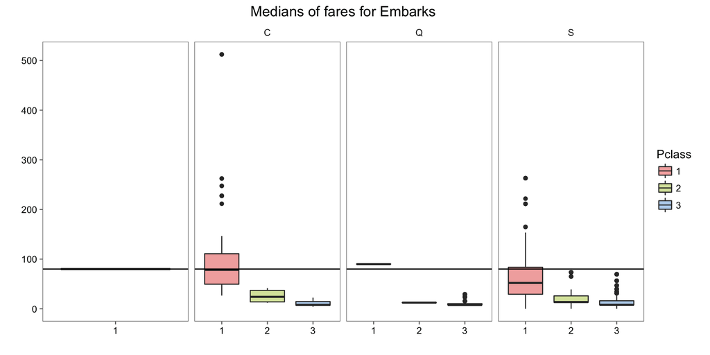

```r
#graph and hline at 80
ggplot(titanic, aes(x = Pclass, y = Fare, fill = Pclass)) +
  geom_boxplot() +
  facet_grid(~Embarked, scales = "free") +
  geom_hline(aes(yintercept=80)) +
  theme_few() +
  scale_fill_few() +
  xlab("") +
  ylab("") +
  ggtitle("Medians of fares for Embarks")
```

```r
titanic[, .(median = median(Fare)), by = .(Embarked, Pclass)][order(Embarked)]
```

```
##     Embarked Pclass  median
##  1:               1 80.0000
##  2:        C      1 78.2667
##  3:        C      2 24.0000
##  4:        C      3  7.8958
##  5:        Q      3  7.7500
##  6:        Q      1 90.0000
##  7:        Q      2 12.3500
##  8:        S      3  8.0500
##  9:        S      1 52.0000
## 10:        S      2 13.5000
```

It looks like the user is similarly grouped at embarkment C based on the median fare. Let’s plug it in.

```r
titanic$Embarked[titanic$Embarked == ""] <- "C"
```

### 3.3 Missing ages

```r
#The rest of the missing information is found in the Age column
sum(is.na(titanic))
```

```
## [1] 177
```

```r
sum(is.na(titanic$Age))
```

```
## [1] 177
```

Imputation for this one isn’t as easy as the last one. It will require a model or other packages like MICE to complete. For now we will use feature engineering.

### 3.4 Feature engineering

```r
#use feature engineering to find missing values of age. Let's extract titles from passenger's names
titanic$Title <- gsub('(.*, )|(\\..*)', '', titanic$Name)

#using wikipedia they define the title master as a boy younger than 16. Trying to fill in NAs for age
#will prove difficult unless we use a predictive model since NA ages include females that do not have a
#corresponding term for younger than 16.

#verification
titanic[is.na(Age), .(Title, Name, Sex, Age)]
```

```
##      Title                                       Name    Sex Age
##   1:    Mr                           Moran, Mr. James   male  NA
##   2:    Mr               Williams, Mr. Charles Eugene   male  NA
##   3:   Mrs                    Masselmani, Mrs. Fatima female  NA
##   4:    Mr                    Emir, Mr. Farred Chehab   male  NA
##   5:  Miss            O'Dwyer, Miss. Ellen ""Nellie"" female  NA
##  ---
## 173:    Mr                           Razi, Mr. Raihed   male  NA
## 174:  Miss        Sage, Miss. Dorothy Edith ""Dolly"" female  NA
## 175:    Mr                van Melkebeke, Mr. Philemon   male  NA
## 176:    Mr                         Laleff, Mr. Kristo   male  NA
## 177:  Miss Johnston, Miss. Catherine Helen ""Carrie"" female  NA
```

# 4 Feature engineering

We will need to extract more useful information out of our data if we want to make a good model.

# 4.1 Creating a family

```r
#Creating a family by adding siblings(SibSp) + parents(Parch) + and self
str(titanic)
```

```
## Classes 'data.table' and 'data.frame':   891 obs. of  13 variables:
##  $ PassengerId: int  1 2 3 4 5 6 7 8 9 10 ...
##  $ Survived   : Factor w/ 2 levels "0","1": 1 2 2 2 1 1 1 1 2 2 ...
##  $ Pclass     : Factor w/ 3 levels "1","2","3": 3 1 3 1 3 3 1 3 3 2 ...
##  $ Name       : chr  "Braund, Mr. Owen Harris" "Cumings, Mrs. John Bradley (Florence Briggs Thayer)" "Heikkinen, Miss. Laina" "Futrelle, Mrs. Jacques Heath (Lily May Peel)" ...
##  $ Sex        : Factor w/ 2 levels "female","male": 2 1 1 1 2 2 2 2 1 1 ...
##  $ Age        : num  22 38 26 35 35 NA 54 2 27 14 ...
##  $ SibSp      : int  1 1 0 1 0 0 0 3 0 1 ...
##  $ Parch      : int  0 0 0 0 0 0 0 1 2 0 ...
##  $ Ticket     : chr  "A/5 21171" "PC 17599" "STON/O2. 3101282" "113803" ...
##  $ Fare       : num  7.25 71.28 7.92 53.1 8.05 ...
##  $ Cabin      : chr  "" "C85" "" "C123" ...
##  $ Embarked   : Factor w/ 4 levels "","C","Q","S": 4 2 4 4 4 3 4 4 4 2 ...
##  $ Title      : chr  "Mr" "Mrs" "Miss" "Mrs" ...
##  - attr(*, ".internal.selfref")=<externalptr>
##  - attr(*, "index")= int
```

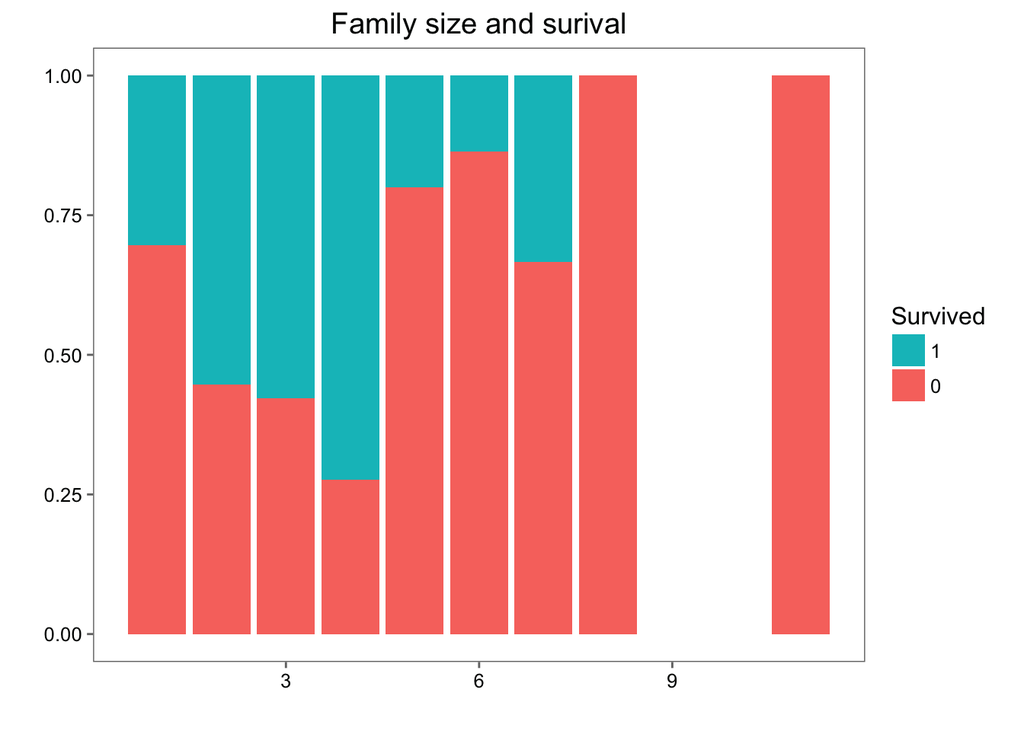

```r
titanic$Fam <- (titanic$SibSp + titanic$Parch + 1)

#Looks like there is a rise in death for family sizes over 4. It may be worth it to create a dummy variable for this.
ggplot(titanic, aes(x = Fam, fill = Survived)) +
  geom_bar(position = "fill") +
  theme_few() +
  xlab("") +
  ylab("") +
  ggtitle("Family size and surival") +
  guides(fill = guide_legend(reverse=TRUE))
```

```r
titanic[,Fam.Five := ifelse(titanic$Fam >= 5, 1, 0)]

#Let's verify
titanic[Fam.Five == 1, .(Fam, Fam.Five)]
```

```
##     Fam Fam.Five
##  1:   5        1
##  2:   7        1
##  3:   6        1
##  4:   5        1
##  5:   7        1
##  6:   6        1
##  7:   6        1
##  8:   8        1
##  9:   6        1
## 10:   7        1
## 11:   8        1
## 12:   5        1
## 13:   6        1
## 14:   7        1
```

[output cut: 49 more lines]

### 4.2 Cabin numbers

Depending on where the cabin is located perhaps the passenger has a higher rate of survival

```r
#Cabin feature creation. $First letter
head(titanic$Cabin, 10)
```

```
##  [1] ""     "C85"  ""     "C123" ""     ""     "E46"  ""     ""     ""
```

```r
titanic[, Cab.Letter := substr(Cabin, 1,1)]

titanic$Cab.Letter[titanic$Cab.Letter == ""] <- "Unknown"

#1 digit number
titanic[, Cabin.1digit := ifelse(nchar(Cabin) == 2, 1, 0)]

#2 digit number
titanic[, Cabin.2digit := ifelse(nchar(Cabin) == 3, 1, 0)]

#3 digit number
titanic[, Cabin.3digit := ifelse(nchar(Cabin) == 4, 1, 0)]

#multiple rooms
titanic[, Cabin.Multiple := ifelse(nchar(Cabin) > 4, 1, 0)]

#one look before we move forward
str(titanic)
```

```
## Classes 'data.table' and 'data.frame':   891 obs. of  20 variables:
##  $ PassengerId   : int  1 2 3 4 5 6 7 8 9 10 ...
##  $ Survived      : Factor w/ 2 levels "0","1": 1 2 2 2 1 1 1 1 2 2 ...
##  $ Pclass        : Factor w/ 3 levels "1","2","3": 3 1 3 1 3 3 1 3 3 2 ...
##  $ Name          : chr  "Braund, Mr. Owen Harris" "Cumings, Mrs. John Bradley (Florence Briggs Thayer)" "Heikkinen, Miss. Laina" "Futrelle, Mrs. Jacques Heath (Lily May Peel)" ...
##  $ Sex           : Factor w/ 2 levels "female","male": 2 1 1 1 2 2 2 2 1 1 ...
##  $ Age           : num  22 38 26 35 35 NA 54 2 27 14 ...
##  $ SibSp         : int  1 1 0 1 0 0 0 3 0 1 ...
##  $ Parch         : int  0 0 0 0 0 0 0 1 2 0 ...
##  $ Ticket        : chr  "A/5 21171" "PC 17599" "STON/O2. 3101282" "113803" ...
##  $ Fare          : num  7.25 71.28 7.92 53.1 8.05 ...
##  $ Cabin         : chr  "" "C85" "" "C123" ...
##  $ Embarked      : Factor w/ 4 levels "","C","Q","S": 4 2 4 4 4 3 4 4 4 2 ...
##  $ Title         : chr  "Mr" "Mrs" "Miss" "Mrs" ...
##  $ Fam           : num  2 2 1 2 1 1 1 5 3 2 ...
##  $ Fam.Five      : num  0 0 0 0 0 0 0 1 0 0 ...
##  $ Cab.Letter    : chr  "Unknown" "C" "Unknown" "C" ...
##  $ Cabin.1digit  : num  0 0 0 0 0 0 0 0 0 0 ...
##  $ Cabin.2digit  : num  0 1 0 0 0 0 1 0 0 0 ...
##  $ Cabin.3digit  : num  0 0 0 1 0 0 0 0 0 0 ...
##  $ Cabin.Multiple: num  0 0 0 0 0 0 0 0 0 0 ...
##  - attr(*, ".internal.selfref")=<externalptr>
##  - attr(*, "index")= atomic
##   ..- attr(*, "__Fam.Five")= int  1 2 3 4 5 6 7 9 10 11 ...
```

# 5 RandomForest

Now that we have numerous features, we must now prepare to train and test our model

```r
#Set up factors for randomForest
titanic$Title <- as.factor(titanic$Title)
titanic$Cab.Letter <- as.factor(titanic$Cab.Letter)
titanic$Cabin.1digit <- as.factor(titanic$Cabin.1digit)
titanic$Cabin.2digit <- as.factor(titanic$Cabin.2digit)
titanic$Cabin.3digit <- as.factor(titanic$Cabin.3digit)
titanic$Cabin.Multiple <- as.factor(titanic$Cabin.Multiple)
```

### 5.1 Splitting our data

We’ll use the package Caret to split our training data to 85% of the data and use the remaining 15% for testing.

```r
#Set up training and test data set
set.seed(2)
split <- createDataPartition(titanic$Survived, p = .85, list = FALSE)

training <- titanic[split,]
testing <- titanic[-split,]

nrow(training)
```

```
## [1] 758
```

```r
nrow(testing)
```

```
## [1] 133
```

### 5.2 Creating our model

Not shown here: iterative feature selection testing. The best combination are the following.

```r
#Create model
m1 <- randomForest(Survived ~ Pclass + Sex + Fare + Fam.Five + Title +
                    Cabin.2digit, data = training, importance = TRUE)
```

### 5.3 Our model

```r
m1
```

```
##
## Call:
##  randomForest(formula = Survived ~ Pclass + Sex + Fare + Fam.Five +      Title + Cabin.2digit, data = training, importance = TRUE)
##                Type of random forest: classification
##                      Number of trees: 500
## No. of variables tried at each split: 2
##
##         OOB estimate of  error rate: 16.49%
## Confusion matrix:
##     0   1 class.error
## 0 415  52   0.1113490
## 1  73 218   0.2508591
```

```r
m1$importance
```

```
##                       0           1 MeanDecreaseAccuracy MeanDecreaseGini
## Pclass       0.02222245 0.064567623           0.03855407         23.90875
## Sex          0.10673219 0.010809892           0.06956633         48.37932
## Fare         0.02724803 0.048656907           0.03558881         34.78317
## Fam.Five     0.03926752 0.005543934           0.02617930         14.36856
## Title        0.20836522 0.141045168           0.18198511         74.52401
## Cabin.2digit 0.01585766 0.002087758           0.01053846          6.70082
```

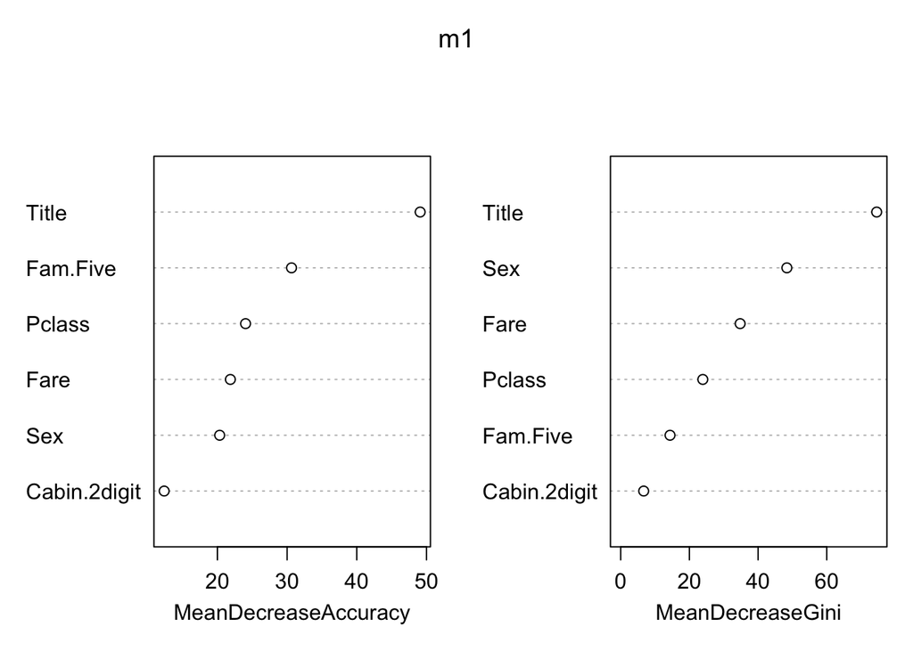

```r
varImpPlot(m1)
```

### 5.4 Testing our model

```r
#Test model
p1 <- predict(m1, testing)
```

### 5.5 Results

```r
table(testing$Survived, p1)
```

```
##    p1
##      0  1
##   0 80  2
##   1 15 36
```

```r
mean(testing$Survived == p1)
```

```
## [1] 0.8721805
```